# Global Handwashing Access and Child Health

- Show All Code
- Hide All Code
- View Source

A UNICEF Data Analysis Report

Author

Swithaja Nagiri

Published

April 26, 2025

## Introduction

This report looks at the problem of not having enough access to handwashing facilities around the world and how it affects health. Using data from UNICEF, we analyze how many people in different countries and regions don’t have access to basic handwashing facilities. We also explore how access to handwashing is connected to life expectancy and economic factors.

Washing hands with soap is one of the most affordable ways to improve public health, potentially cutting down diarrhea by up to 50% and respiratory infections by 25%. Even though it’s so important, many people around the world still don’t have access to handwashing facilities, putting them at higher risk for preventable diseases.

```python
# Import necessary libraries
import pandas as pd
import numpy as np
import plotnine as p9
import geopandas as gpd
from plotnine import *
import statsmodels.api as sm
import geodatasets
import matplotlib.pyplot as plt
```

```python
# Data loading, the cleaned, filtered, sorted and merged data from indicators and metadata
unicef_data = pd.read_csv(r"C:\Users\Swithaja N\Documents\DCU\2nd Sem\Data Analytics\Assignment 2\unicef-report\merged_unicef_data.csv.csv")

# First few rows of the dataset
unicef_data.head()
```

|  | country | year | limited_handwashing_percent | Population, total | GDP per capita (constant 2015 US$) | Life expectancy at birth, total (years) | Hospital beds (per 1,000 people) |
| --- | --- | --- | --- | --- | --- | --- | --- |
| 0 | Afghanistan | 2005 | 25.015464 | 24404567.0 | 363.640141 | 58.361 | 0.42 |
| 1 | Afghanistan | 2006 | 24.989365 | 25424094.0 | 367.758312 | 58.684 | 0.42 |
| 2 | Afghanistan | 2007 | 24.963012 | 25909852.0 | 410.757729 | 59.111 | 0.42 |
| 3 | Afghanistan | 2008 | 24.936531 | 26482622.0 | 417.647283 | 59.852 | 0.42 |
| 4 | Afghanistan | 2009 | 24.909920 | 27466101.0 | 488.830652 | 60.364 | 0.42 |

## Geographic Patterns of Handwashing Access

The map below shows the percentage of the population with limited access to handwashing facilities in different countries, highlighting geographic differences.

[output not shown]

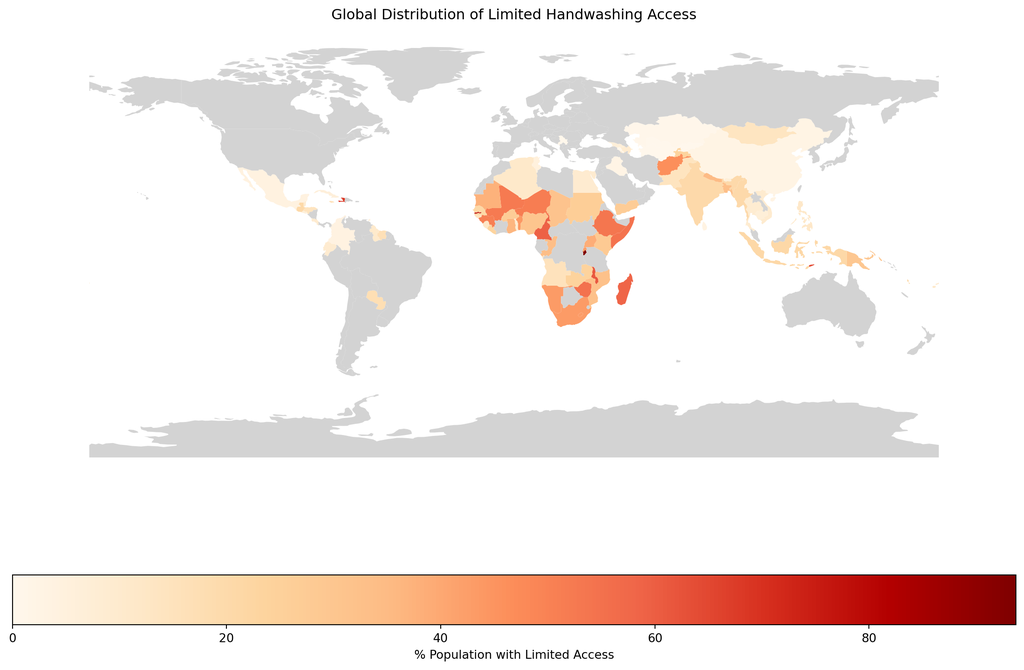

```python
# Finding available Natural Earth datasets
try:
    # Option 1: Use GeoPandas built-in naturalearth_lowres dataset
    world = gpd.read_file(gpd.datasets.get_path('naturalearth_lowres'))
    print("Columns in world GeoDataFrame:", world.columns)  # Debug: Check column names
except Exception as e:
    print(f"Error using GeoPandas dataset: {e}")
    try:
        # Option 2: Direct download from Natural Earth
        import requests
        import tempfile
        import zipfile
        import os

        url = "https://naciscdn.org/naturalearth/110m/cultural/ne_110m_admin_0_countries.zip"
        response = requests.get(url)
        response.raise_for_status()

        with tempfile.TemporaryDirectory() as tmpdir:
            zip_path = os.path.join(tmpdir, "ne_countries.zip")
            with open(zip_path, 'wb') as f:
                f.write(response.content)

            with zipfile.ZipFile(zip_path, 'r') as zip_ref:
                zip_ref.extractall(tmpdir)

            shp_path = os.path.join(tmpdir, "ne_110m_admin_0_countries.shp")
            world = gpd.read_file(shp_path)
            print("Columns in downloaded world GeoDataFrame:", world.columns)  # Debug
    except Exception as e:
        print(f"Failed to download Natural Earth data: {e}")
        raise

# Create recent_data from unicef_data (if not already created)
# This assumes that the unicef_data dataset contains the columns 'country' and 'year'.
recent_data = unicef_data.sort_values('year').groupby('country').last().reset_index()
print("Columns in recent_data:", recent_data.columns)  # Debug

# Merge the data with the world map
# Try using standard column names for country names in the Natural Earth dataset.
possible_country_columns = ['name', 'NAME', 'NAME_LONG', 'admin', 'country', 'COUNTRY', 'ADMIN', 'SOVEREIGNT']
merge_successful = False

for col in possible_country_columns:
    if col in world.columns:
        try:
            merged_data = world.merge(recent_data, left_on=col, right_on='country', how='left')
            print(f"Successfully merged on column: {col}")
            merge_successful = True
            break
        except Exception as e:
            print(f"Failed to merge on column {col}: {e}")

if not merge_successful:
    # If no direct match found, try case-insensitive comparison
    world_lower = world.copy()
    for col in world.columns:
        if col.isupper():
            world_lower[col.lower()] = world[col].str.lower()

    recent_data['country_lower'] = recent_data['country'].str.lower()

    for col in world_lower.columns:
        if col.endswith('_lower'):
            try:
                merged_data = world.merge(recent_data, left_on=col.replace('_lower', ''),
                                         right_on='country', how='left')
                print(f"Successfully merged on modified column: {col}")
                merge_successful = True
                break
            except Exception as e:
                print(f"Failed to merge on modified column {col}: {e}")

if not merge_successful:
    raise KeyError("Could not find a suitable column in the world data to merge with 'country' in recent_data")

# Create the map visualization
fig, ax = plt.subplots(1, 1, figsize=(12, 8))
merged_data.plot(column='limited_handwashing_percent', ax=ax, legend=True,
                cmap='OrRd', legend_kwds={'label': "% Population with Limited Access",
                                         'orientation': "horizontal"},
                missing_kwds={'color': 'lightgrey'})
ax.set_title("Global Distribution of Limited Handwashing Access")
ax.set_axis_off()
plt.tight_layout()
plt.show()
```

## Regional Analysis of Handwashing Access

To see regional patterns, compare the average percentage of people with limited handwashing access in different world regions.

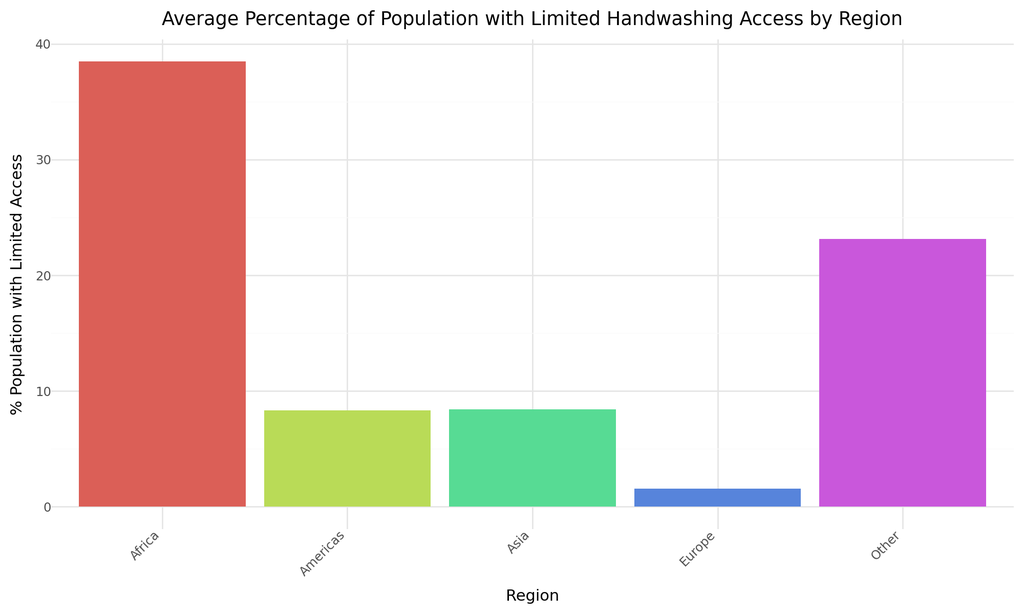

Regional comparison of limited handwashing access

```python
# Get most recent data for each country
recent_data = unicef_data.sort_values('year').groupby('country').last().reset_index()

# Create a region column by grouping countries

regions = {
    'Africa': ['Afghanistan', 'Algeria', 'Angola', 'Benin', 'Burkina Faso', 'Burundi',
               'Cameroon', 'Central African Republic', 'Chad', 'Zambia', 'Zimbabwe'],
    'Asia': ['Armenia', 'Azerbaijan', 'Bahrain', 'Bangladesh', 'Bhutan', 'Cambodia', 'China'],
    'Americas': ['Barbados', 'Belize', 'Bolivia, Plurinational State of'],
    'Europe': ['Bosnia and Herzegovina']
}

# Create a region column
def assign_region(country):
    for region, countries in regions.items():
        if country in countries:
            return region
    return 'Other'

recent_data['region'] = recent_data['country'].apply(assign_region)

# Group by region and calculate mean
region_data = recent_data.groupby('region')['limited_handwashing_percent'].mean().reset_index()
region_data = region_data.sort_values(by='limited_handwashing_percent', ascending=False)

# Create the bar chart
(ggplot(region_data, aes(x='region', y='limited_handwashing_percent', fill='region')) +
 geom_bar(stat='identity') +
 theme_minimal() +
 theme(axis_text_x=element_text(angle=45, hjust=1),
       figure_size=(10, 6)) +
 labs(title="Average Percentage of Population with Limited Handwashing Access by Region",
      x="Region",
      y="% Population with Limited Access") +
 guides(fill=False))
```

## Impact of Handwashing Access on Health Outcomes

### Relationship Between Handwashing Access and Life Expectancy

This scatter plot shows the link between limited handwashing access and life expectancy, with a regression line showing the overall trend.

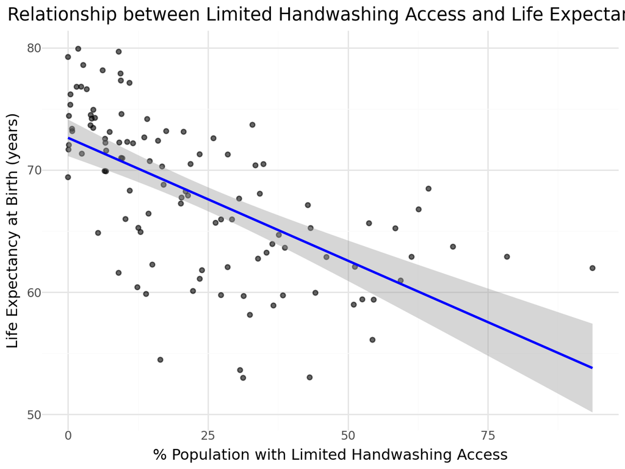

Correlation between limited handwashing access and life expectancy

```python
# Use most recent data for each country
scatter_data = recent_data.dropna(subset=['limited_handwashing_percent', 'Life expectancy at birth, total (years)'])

# Create the scatter plot with regression line
(ggplot(scatter_data, aes(x='limited_handwashing_percent',
                           y='Life expectancy at birth, total (years)')) +
 geom_point(alpha=0.6) +
 geom_smooth(method='lm', color='blue') +
 theme_minimal() +
 labs(title="Relationship between Limited Handwashing Access and Life Expectancy",
      x="% Population with Limited Handwashing Access",
      y="Life Expectancy at Birth (years)"))
```

```python
# Calculate regression statistics
X = scatter_data['limited_handwashing_percent']
X = sm.add_constant(X)
y = scatter_data['Life expectancy at birth, total (years)']
model = sm.OLS(y, X).fit()
print(model.summary())
```

```
                                       OLS Regression Results
===================================================================================================
Dep. Variable:     Life expectancy at birth, total (years)   R-squared:                       0.380
Model:                                                 OLS   Adj. R-squared:                  0.375
Method:                                      Least Squares   F-statistic:                     65.07
Date:                                     Sat, 26 Apr 2025   Prob (F-statistic):           1.19e-12
Time:                                             22:01:54   Log-Likelihood:                -328.46
No. Observations:                                      108   AIC:                             660.9
Df Residuals:                                          106   BIC:                             666.3
Df Model:                                                1
Covariance Type:                                 nonrobust
===============================================================================================
                                  coef    std err          t      P>|t|      [0.025      0.975]
-----------------------------------------------------------------------------------------------
const                          72.6335      0.754     96.281      0.000      71.138      74.129
limited_handwashing_percent    -0.2010      0.025     -8.067      0.000      -0.250      -0.152
==============================================================================
Omnibus:                        7.753   Durbin-Watson:                   1.919
Prob(Omnibus):                  0.021   Jarque-Bera (JB):                7.736
Skew:                          -0.653   Prob(JB):                       0.0209
Kurtosis:                       3.116   Cond. No.                         46.5
==============================================================================

Notes:
[1] Standard Errors assume that the covariance matrix of the errors is correctly specified.
```

## Temporal Trends in Handwashing Access

### Changes in Handwashing Access Over Time

The following time series chart shows how limited handwashing access has changed over time in selected countries, helping us see progress or setbacks.

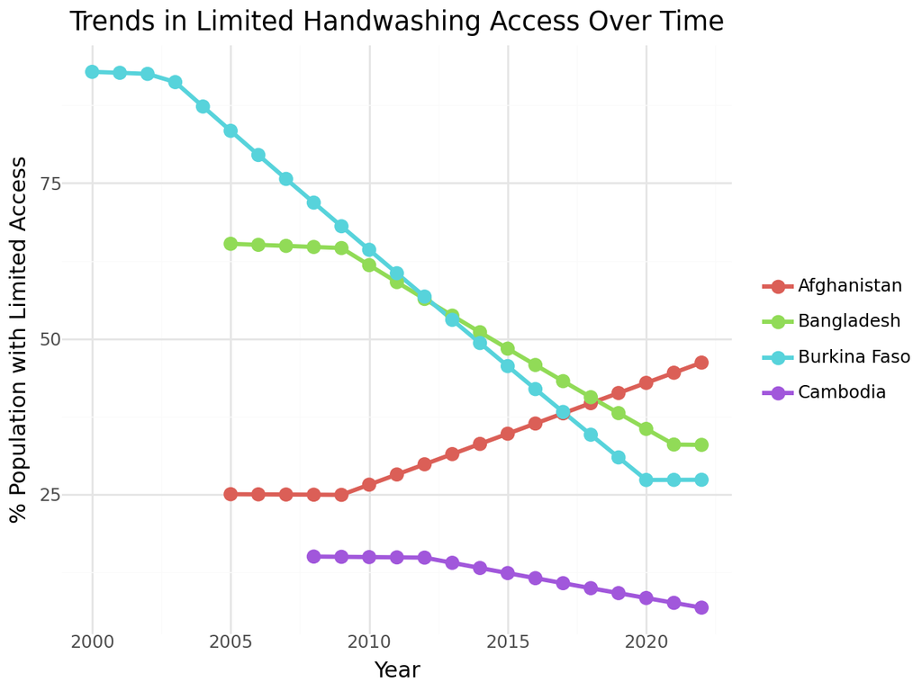

Trends in limited handwashing access over time in selected countries

```python
# Select few countries with complete time series data
countries_to_plot = ['Bangladesh', 'Afghanistan', 'Burkina Faso', 'Cambodia']
time_data = unicef_data[unicef_data['country'].isin(countries_to_plot)]

# Create the time series plot
(ggplot(time_data, aes(x='year', y='limited_handwashing_percent', color='country', group='country')) +
 geom_line(size=1.2) +
 geom_point(size=3) +
 theme_minimal() +
 scale_x_continuous(breaks=range(2000, 2023, 5)) +
 labs(title="Trends in Limited Handwashing Access Over Time",
      x="Year",
      y="% Population with Limited Access") +
 theme(legend_title=element_blank()))
```

## Conclusions

Based on the analysis of UNICEF data on handwashing access, several key findings emerge: